# NYC Flights - data wrangling II

Author

Published

September 22, 2026

We will again work with data from the `nycflights13` package.

```r
library(nycflights13)
library(tidyverse)
```

## Exercise 1

Examine the documentation for the datasets `airports`, `flights`, and `planes`. What are the dimensions of each? What variables do they have in common that would allow them to be linked together? Note: variables may not be named the same thing in each dataset!

## EXAMPLE

Suppose you wanted to make a map of the route of every flight. What variables would you need from which datasets? You need the geographic location of the airports (from `airports`) and the path of flights (i.e., which airports were involved) from `flights`.

We want to join flights to airports. Note these two datasets have no variables in common so we will have to specify the variable to join by using `by =`. Check out the documentation for more information.

```r
flights |>
  left_join(airports, by = c("dest" = "faa"))
```

```
# A tibble: 336,776 × 26
    year month   day dep_time sched_dep_time dep_delay arr_time sched_arr_time
   <int> <int> <int>    <int>          <int>     <dbl>    <int>          <int>
 1  2013     1     1      517            515         2      830            819
 2  2013     1     1      533            529         4      850            830
 3  2013     1     1      542            540         2      923            850
 4  2013     1     1      544            545        -1     1004           1022
 5  2013     1     1      554            600        -6      812            837
 6  2013     1     1      554            558        -4      740            728
 7  2013     1     1      555            600        -5      913            854
 8  2013     1     1      557            600        -3      709            723
 9  2013     1     1      557            600        -3      838            846
10  2013     1     1      558            600        -2      753            745
# ℹ 336,766 more rows
# ℹ 18 more variables: arr_delay <dbl>, carrier <chr>, flight <int>,
#   tailnum <chr>, origin <chr>, dest <chr>, air_time <dbl>, distance <dbl>,
#   hour <dbl>, minute <dbl>, time_hour <dttm>, name <chr>, lat <dbl>,
#   lon <dbl>, alt <dbl>, tz <dbl>, dst <chr>, tzone <chr>
```

## Exercise 2

Which airports are in `flights` but not in `airports`? Google to find out what these airports are.

```r
flights |>
  anti_join(airports, by = c("dest" = "faa")) |>
  distinct(dest)
```

```
# A tibble: 4 × 1
  dest
  <chr>
1 BQN
2 SJU
3 STT
4 PSE
```

Which airports are in `airports` but not in `flights`? What does this tell us about these airports (at least in 2013)?

```r
airports |>
  anti_join(flights, by = c("faa" = "dest")) |>
  distinct(faa)
```

```
# A tibble: 1,357 × 1
   faa
   <chr>
 1 04G
 2 06A
 3 06C
 4 06N
 5 09J
 6 0A9
 7 0G6
 8 0G7
 9 0P2
10 0S9
# ℹ 1,347 more rows
```

## Exercise 3

Starting with the `flights` dataset, create a new dataset `dest_delays` with the median arrival delay for each destination. *Note, this question does not require you to use joins. Make sure to add na.rm = TRUE when computing the median. Check: `dest_delays` should have dimensions 105 x 2.*

```r
dest_delays <- flights |>
  group_by(dest) |>
  summarize(med_arr_delay = median(arr_delay, na.rm = TRUE))
```

## Exercise 4

Join the columns in `airports` to `dest_delays` (preserving all rows in `dest_delays` and save the new dataset into `delays_by_airport`. *Check: `delays_by_airport`* *should have dimensions 105 x 9.*

```r
delays_by_airport <- dest_delays |>
  left_join(airports, by = c("dest" = "faa"))

airports |>
  right_join(dest_delays, by = c("faa" = "dest"))
```

```
# A tibble: 105 × 9
   faa   name                   lat    lon   alt    tz dst   tzone med_arr_delay
   <chr> <chr>                <dbl>  <dbl> <dbl> <dbl> <chr> <chr>         <dbl>
 1 ABQ   Albuquerque Interna…  35.0 -107.   5355    -7 A     Amer…          -5.5
 2 ACK   Nantucket Mem         41.3  -70.1    48    -5 A     Amer…          -3
 3 ALB   Albany Intl           42.7  -73.8   285    -5 A     Amer…          -4
 4 ANC   Ted Stevens Anchora…  61.2 -150.    152    -9 A     Amer…           1.5
 5 ATL   Hartsfield Jackson …  33.6  -84.4  1026    -5 A     Amer…          -1
 6 AUS   Austin Bergstrom In…  30.2  -97.7   542    -6 A     Amer…          -5
 7 AVL   Asheville Regional …  35.4  -82.5  2165    -5 A     Amer…          -1
 8 BDL   Bradley Intl          41.9  -72.7   173    -5 A     Amer…         -10
 9 BGR   Bangor Intl           44.8  -68.8   192    -5 A     Amer…          -9
10 BHM   Birmingham Intl       33.6  -86.8   644    -6 A     Amer…          -2
# ℹ 95 more rows
```

Based on your answer to Exercise 2, how many rows in `delays_by_airport` do you expect to be missing latitude and longitude information?

## Exercise 5

*Is there a relationship between the age of a plane and its delays?* The plane tail number is given in the `tailnum` variable in the `flights` dataset. The year the plane was manufactured is given in the `year` variable in the `planes` dataset.

Start by finding the median arrival delay for each plane and store the resulting dataset in `plane_delays`. *Check: `plane_delays`* *should have dimensions 4044 x 2*

```r
plane_delays <- flights |>
  group_by(tailnum) |>
  summarize(med_arr_delay = median(arr_delay, na.rm = TRUE))
```

Join `plane_delays` to the `planes` data using an appropriate join and then use `mutate` to create an `age` variable. Note this data is from 2013.

```r
delays_by_plane <- planes |>
  left_join(plane_delays) |>
  mutate(age = 2013 - year)
```

Finally, create an effective visualization of the data to investigate if there a relationship between the age of a plane and its delays. Comment on your conclusions.

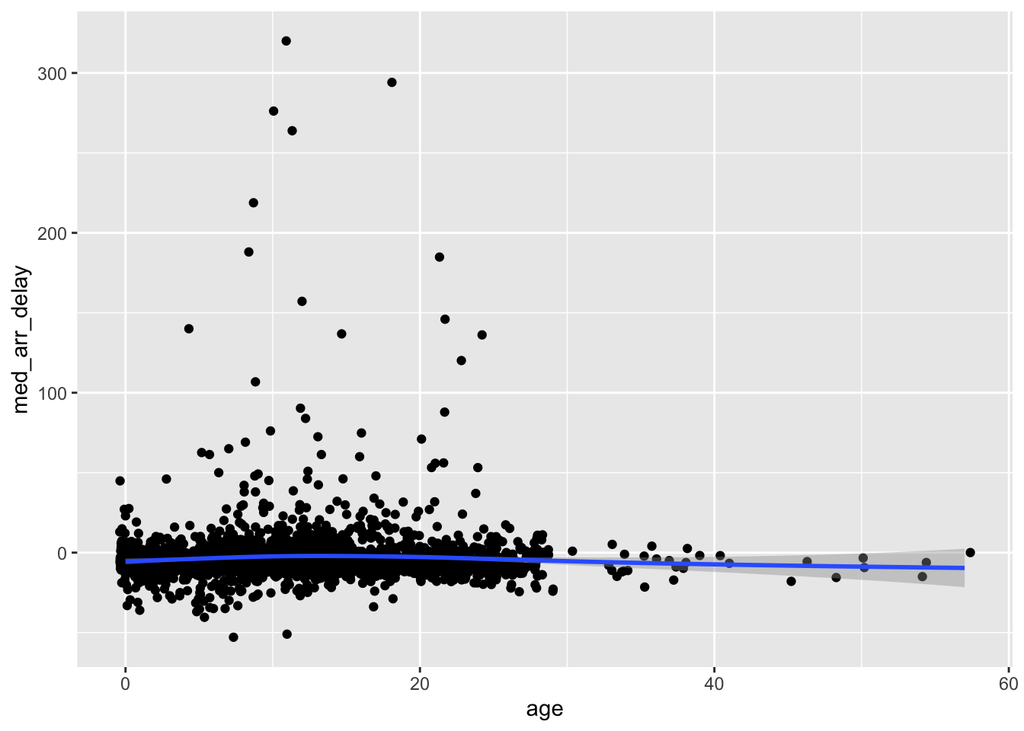

```r
ggplot(delays_by_plane, aes(x = age, y = med_arr_delay)) +
  geom_jitter() +
  geom_smooth()
```

## (FOR LATER) Extra mapping fun

We will try re-creating the visualization below and/or exploring other ways to visualized the flights data spatially. *Note, to view the image in your html, download the “flights_map.png” file and place it in a (new) images subfolder of your STAT_7500 folder.*

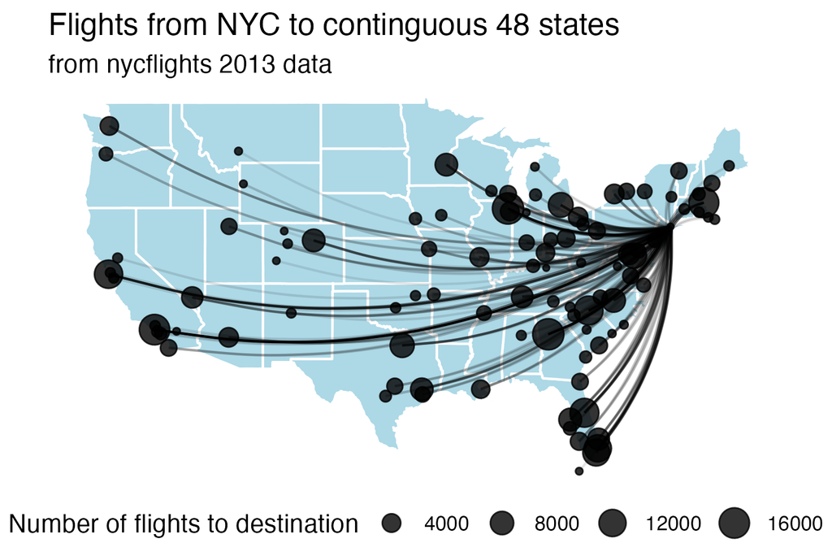

Some starter code is provided below for creating a basic US map.

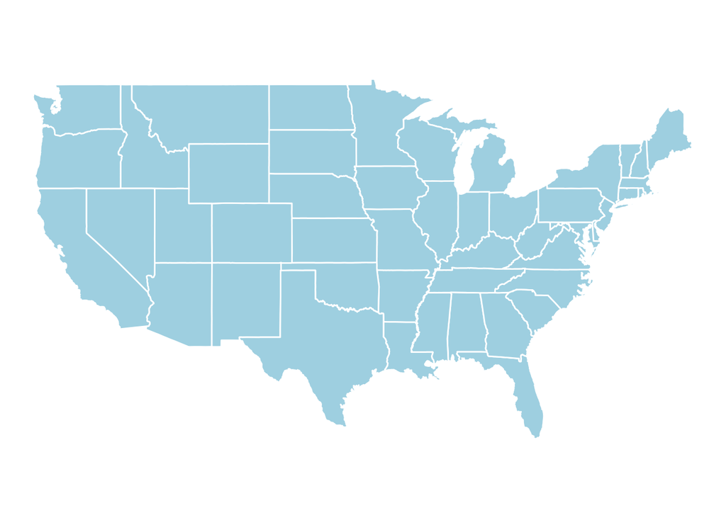

```r
library(maps)
library(mapdata)

state <- map_data("state")



ggplot() +
  geom_polygon(data = state,
               aes(x = long, y = lat, group = group),
               fill = 'lightblue', color = "white") +
  theme_void() +
  coord_fixed(1.3)
```

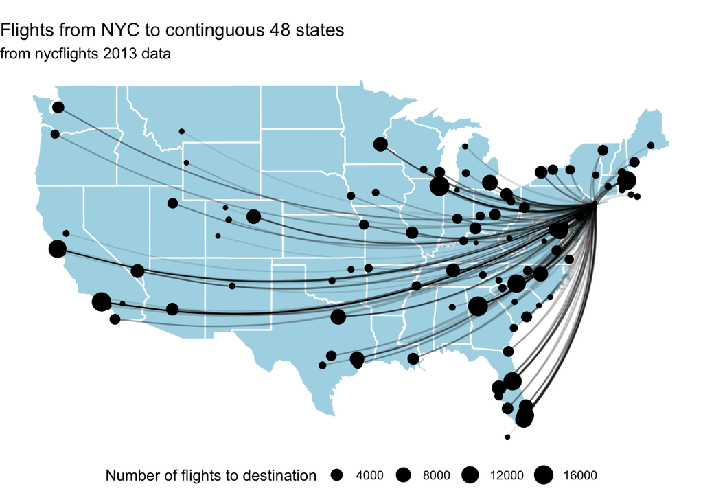

```r
dest_counts <- flights |>
  count(dest, name = "n_flights") |>
  left_join(airports, by = c("dest" = "faa")) |>
  filter(!(dest %in% c("HNL", "ANC")))

paths <- flights |>
  count(dest, origin, name = "n_flights") |>
  left_join(airports |> select(faa, lat, lon),
            by = c("dest" = "faa")) |>
  rename(lat_d = lat, lon_d = lon) |>
  left_join(airports |> select(faa, lat, lon),
            by = c("origin" = "faa")) |>
  rename(lat_o = lat, lon_o = lon) |>
  filter(!(dest %in% c("HNL", "ANC")))

ggplot() +
  geom_polygon(data = state,
               aes(x = long, y = lat, group = group),
               fill = 'lightblue', color = "white") +
  geom_point(data = dest_counts, aes(x = lon, y = lat,
                                     size = n_flights)) +
  geom_curve(data = paths, aes(x = lon_o, xend = lon_d,
                               y = lat_o, yend = lat_d,
                               alpha = n_flights),
             curvature = -0.2) +
  theme_void() +
  coord_fixed(1.3) +
  theme(legend.position = "bottom") +
  guides(alpha = "none") +
  labs(title = "Flights from NYC to continguous 48 states",
       subtitle = "from nycflights 2013 data",
       size = "Number of flights to destination")
```